# Exercises_Session 2 & 4 - Species Description & Adding References

by Virginia Palchetti

# 1 *Lycium humile* Phil.

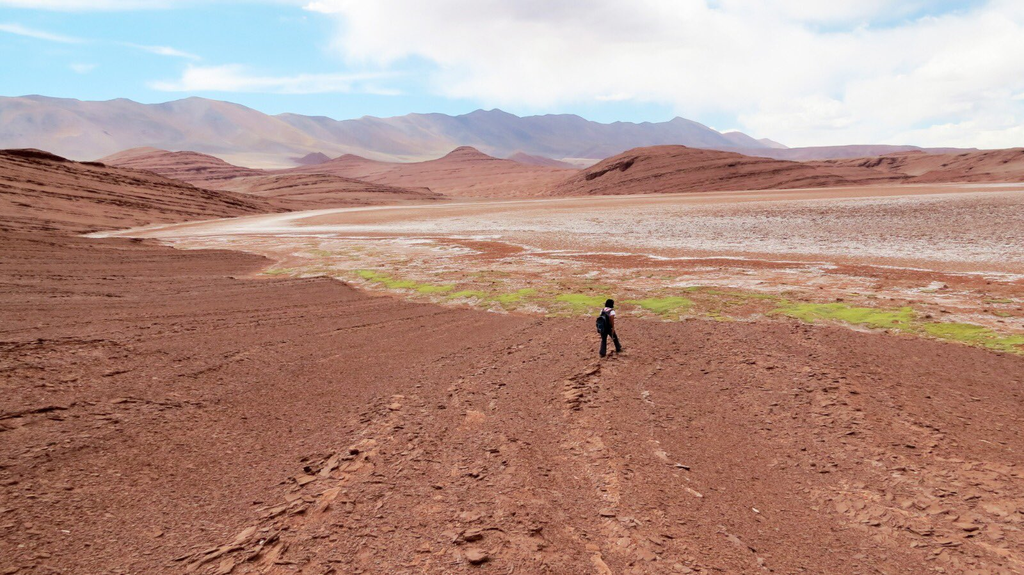

This plant is one of the most salt-tolerant Solanaceae species in the world. Therefore, it is an exciting experimental model to study tolerance to salinity and responses to multiple stresses in Solanaceae (Palchetti et al. 2021a).

## 1.1 Taxlist object

The following command lines are required to create the taxlist object with its taxonomy.

–Load the package taxlist:

```r
library(taxlist)
```

–Create an empty taxlist object using the function new():

```r
Lycium_sp <- new("taxlist")
Lycium_sp
```

```
## object size: 5.1 Kb
## validation of 'taxlist' object: TRUE
##
## number of taxon usage names: 0
## number of taxon concepts: 0
## trait entries: 0
## number of trait variables: 0
## taxon views: 0
```

–Set the respective taxonomic ranks. In such case, the levels have to be provided from the lowest to highest hierarchical level:

```r
levels(Lycium_sp) <- c("species", "genus", "family")
```

–Use the function add_concept() to add a new taxon:

```r
Lycium_sp <- add_concept(taxlist = Lycium_sp, TaxonName = "Solanaceae", AuthorName= "Juss.", Level = "family")
Lycium_sp <- add_concept(taxlist = Lycium_sp, TaxonName = "Lycium", Level = "genus", AuthorName = "L.", Parent = 1)
Lycium_sp <- add_concept(taxlist = Lycium_sp, TaxonName = "Lycium humile", AuthorName = "Phil.", Level = "species", Parent = 2)
Lycium_sp
```

```
## object size: 5.9 Kb
## validation of 'taxlist' object: TRUE
##
## number of taxon usage names: 3
## number of taxon concepts: 3
## trait entries: 0
## number of trait variables: 0
## taxon views: 0
##
## concepts with parents: 2
## concepts with children: 2
##
## hierarchical levels: species < genus < family
## number of concepts in level species: 1
## number of concepts in level genus: 1
## number of concepts in level family: 1
```

–The function summary() is applied to provide on the one side a display of meta-information for the whole taxlist object, and on the other side to show a detail of the taxa included in the object:

```r
summary(Lycium_sp, "all")
```

```
## ------------------------------
## concept ID: 1
## view ID: none
## level: family
## parent: none
##
## # accepted name:
## 1 Solanaceae Juss.
## ------------------------------
## concept ID: 2
## view ID: none
## level: genus
## parent: 1 Solanaceae Juss.
##
## # accepted name:
## 2 Lycium L.
## ------------------------------
## concept ID: 3
## view ID: none
## level: species
## parent: 2 Lycium L.
##
## # accepted name:
## 3 Lycium humile Phil.
## ------------------------------
```

–Alternatively, use the function indented_list(), which provides a better display on the hierarchical strucutre of taxlist objects:

```r
indented_list(Lycium_sp)
```

```
## Solanaceae Juss.
##  Lycium L.
##   Lycium humile Phil.
```

## 1.2 Description

**Anatomy:** This dwarf shrub is easily identified by the prostrate or even mat-forming growth habit and very succulent leaves, and during summer, by the numerous white flowers and blackish berries, which also grow almost on the soil surface (Bernardello 1986).

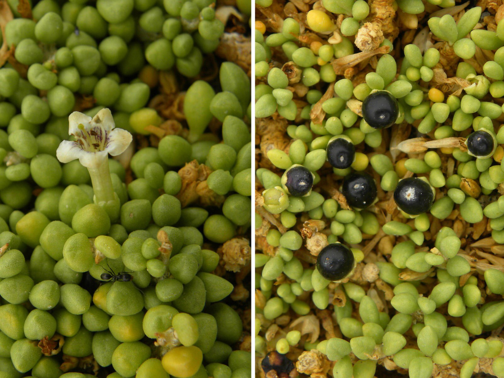

**Ecology:** It preferentially grows in saline clay soils, and less frequently in sandy soils. It is commonly found in saline mudflats of salars (Palchetti et al. 2021b).

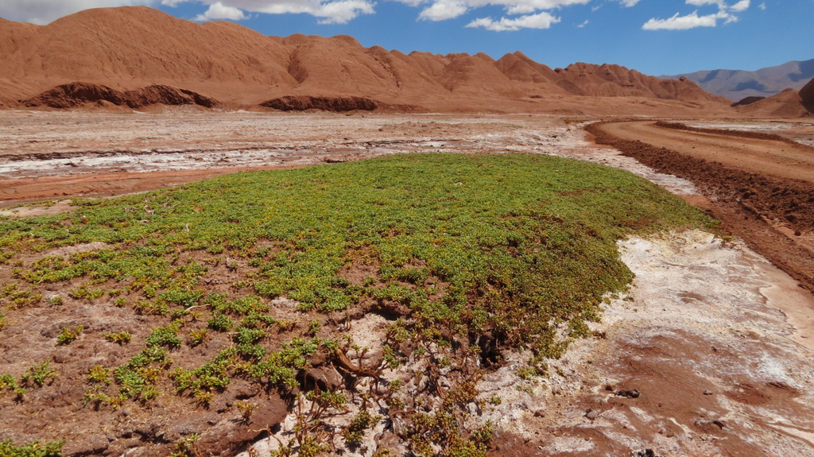

The species occurs in plant communities with low species richness, along with Amaranthaceae, *Nitrophila australis* and *Salicornia pulvinata*; Asteraceae, *Baccharis acaulis*; Frankeniaceae, *Frankenia triandra*; Juncaginaceae, *Triglochin concinna*; and Poaceae, *Distichlis humilis* and *Ditichlis spicata*.

**Distribution:** It is endemic to the Altiplano-Puna region a high-altitude plateau in the Central Andes (South America), distributed at 2300–4100 m elevation, and inhabits extreme environmental conditions such as extreme temperatures, low precipitation, and highly saline soils (Palchetti et al. 2021b).

[figure not shown]

# Reference List

Bernardello G (1986) Revision taxonomica de las especies sudamericanas de lycium (solanaceae). Boletin de la Academia Nacional de Ciencias 57: 173–356.

Palchetti MV, Reginato M, Llanes A, Hornbacher J, Papenbrock J, Barboza GE, Luna V, Cantero JJ (2021a) New insights into the salt tolerance of the extreme halophytic species lycium humile (lycieae, solanaceae). Plant Physiology and Biochemistry 163: 166–177. https://doi.org/10.1016/j.plaphy.2021.03.054

Palchetti MV, Cantero JJ, Morales-Fierro V, Barboza GE, Moreira-Muñoz A (2021b) Living in extreme environments: Distribution of lycium humile (solanaceae), an endemic halophyte from the altiplano-puna region, south america. PhytoKeys 185: 1–15. https://doi.org/10.3897/phytokeys.185.71377